[figure not shown]

*Copyright Pierian Data Inc.*

# Image Processing Assessment

Complete the tasks in bold below! Feel free to treat this as a code along by skipping this assessment lecture and moving straight to the solutions lecture!

**Some Useful Code is already here for you in the cells below:**

```python
import cv2
import matplotlib.pyplot as plt
import numpy as np
%matplotlib inline
```

```python
def display_img(img,cmap=None):
    fig = plt.figure(figsize=(12,10))
    ax = fig.add_subplot(111)
    ax.imshow(img,cmap)
```

**TASK: Open and display the giaraffes.jpg image that is located in the DATA folder.**

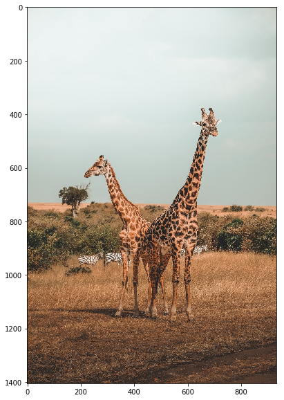

```python
color_giaraffes = cv2.imread('../Data/giraffes.jpg')
show_color_giaraffes = cv2.cvtColor(color_giaraffes,cv2.COLOR_BGR2RGB)
display_img(show_color_giaraffes)
```

**TASK:Apply a binary threshold onto the image.**

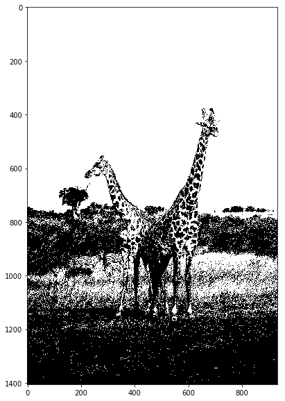

```python
gray_giaraffes = cv2.cvtColor(color_giaraffes,cv2.COLOR_BGR2GRAY)
ret,binary_giaraffe = cv2.threshold(gray_giaraffes,128,255,cv2.THRESH_BINARY)
display_img(binary_giaraffe,'gray')
```

**TASK: Open the giaraffes.jpg file from the DATA folder and convert its colorspace to HSV and display the image.**

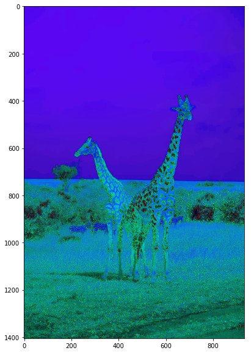

```python
color_ToHSV_giaraffes = cv2.imread('../Data/giraffes.jpg')
hsv_giaraffes = cv2.cvtColor(color_ToHSV_giaraffes,cv2.COLOR_BGR2HSV)
display_img(hsv_giaraffes)
```

```python
kernel = np.ones((4,4),dtype=np.uint8)*(0.1)
print(kernel)
```

```
[[0.1 0.1 0.1 0.1]
 [0.1 0.1 0.1 0.1]
 [0.1 0.1 0.1 0.1]
 [0.1 0.1 0.1 0.1]]
```

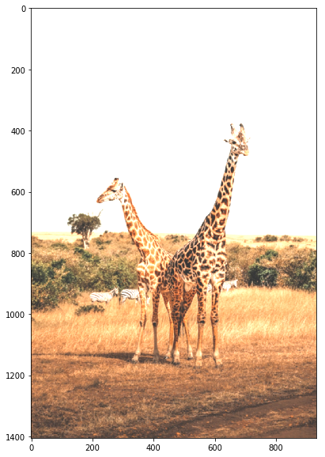

```python
color_giarafees = cv2.imread('../Data/giraffes.jpg')
img = cv2.cvtColor(color_giarafees,cv2.COLOR_BGR2RGB)
blurr_giaraffes = cv2.filter2D(img,-1,kernel)
display_img(blurr_giaraffes)
```

**TASK: Create a Horizontal Sobel Filter (sobelx from our lecture) with a kernel size of 5 to the grayscale version of the giaraffes image and then display the resulting gradient filtered version of the image.**

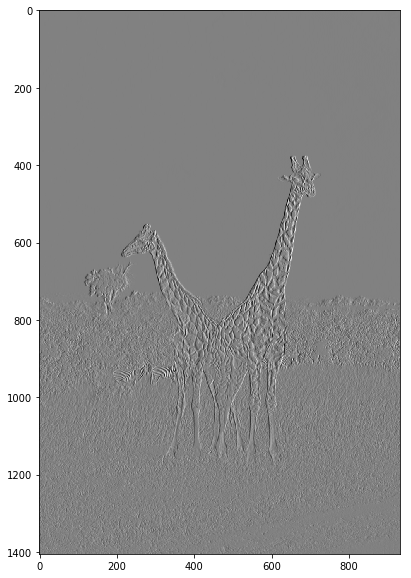

```python
img_gray = cv2.imread('../Data/giraffes.jpg',0)
sobelx = cv2.Sobel(img_gray,cv2.CV_64F,1,0,ksize=5)
display_img(sobelx,'gray')
```

**TASK: Plot the color histograms for the RED, BLUE, and GREEN channel of the giaraffe image. Pay careful attention to the ordering of the channels.**

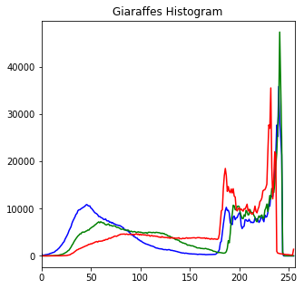

```python
img = cv2.imread('../Data/giraffes.jpg')
fig = plt.figure(figsize=(5,5))
ax = fig.add_subplot(111)

color = ('b','g','r')
for i,col in enumerate(color):
    histr = cv2.calcHist([img],[i],None,[256],[0,256])
    ax.plot(histr,color = col)
    plt.xlim([0,256])
plt.title('Giaraffes Histogram')
plt.show()
```